# Bike Sharing Demand

Mohit Rajput

### Introduction

Bike sharing systems are a means of renting bicycles where the process of obtaining membership, rental, and bike return is automated via a network of kiosk locations throughout a city. Using these systems, people are able rent a bike from a one location and return it to a different place on an as-needed basis. Currently, there are over 500 bike-sharing programs around the world.  
The data generated by these systems makes them attractive for researchers because the duration of travel, departure location, arrival location, and time elapsed is explicitly recorded. Bike sharing systems therefore function as a sensor network, which can be used for studying mobility in a city.

### Research Question

To combine historical usage patterns with weather data in order to forecast bike rental demand in the Capital Bikeshare program.

### Setting up the environment

#### Loading the Packages

Loading the necassary packages for analysis.

```r
library(ggplot2)
library(lattice)
library(caret)
library(corrplot)
library(gridExtra)
library(rpart)
#library(rattle)
library(rpart.plot)
library(randomForest)
library(clusterSim)
```

#### Loading the Data

Reading the CSV into the R environment.

```r
getwd()
```

```
## [1] "C:/(My Work place/( Data Analysis WD/Bike Sharing Demand"
```

```r
training <- read.csv("train.csv",header=TRUE)
testing <- read.csv("test.csv",header=TRUE)
```

###### Discussion

After this file will be read into the R environment.

#### Understanding the Data

Checking the structure of the data

```r
str(training)
```

```
## 'data.frame':    10886 obs. of  12 variables:
##  $ datetime  : Factor w/ 10886 levels "2011-01-01 00:00:00",..: 1 2 3 4 5 6 7 8 9 10 ...
##  $ season    : int  1 1 1 1 1 1 1 1 1 1 ...
##  $ holiday   : int  0 0 0 0 0 0 0 0 0 0 ...
##  $ workingday: int  0 0 0 0 0 0 0 0 0 0 ...
##  $ weather   : int  1 1 1 1 1 2 1 1 1 1 ...
##  $ temp      : num  9.84 9.02 9.02 9.84 9.84 ...
##  $ atemp     : num  14.4 13.6 13.6 14.4 14.4 ...
##  $ humidity  : int  81 80 80 75 75 75 80 86 75 76 ...
##  $ windspeed : num  0 0 0 0 0 ...
##  $ casual    : int  3 8 5 3 0 0 2 1 1 8 ...
##  $ registered: int  13 32 27 10 1 1 0 2 7 6 ...
##  $ count     : int  16 40 32 13 1 1 2 3 8 14 ...
```

Head of the training data

```r
head(training)
```

```
##              datetime season holiday workingday weather temp  atemp
## 1 2011-01-01 00:00:00      1       0          0       1 9.84 14.395
## 2 2011-01-01 01:00:00      1       0          0       1 9.02 13.635
## 3 2011-01-01 02:00:00      1       0          0       1 9.02 13.635
## 4 2011-01-01 03:00:00      1       0          0       1 9.84 14.395
## 5 2011-01-01 04:00:00      1       0          0       1 9.84 14.395
## 6 2011-01-01 05:00:00      1       0          0       2 9.84 12.880
##   humidity windspeed casual registered count
## 1       81    0.0000      3         13    16
## 2       80    0.0000      8         32    40
## 3       80    0.0000      5         27    32
## 4       75    0.0000      3         10    13
## 5       75    0.0000      0          1     1
## 6       75    6.0032      0          1     1
```

###### Discussion

The Dataset contains p=12 i.e 12 variables and n=10886 i.e. 10886 observations. the variable types are as shown below-

| Categorical | Numerical |
| --- | --- |
| datetime | atemp |
| season | temp |
| holiday | humidity |
| workingday | windspeed |
| weather | casual |
|  | registered |
|  | count |

Data Cookbook

| Data Field |  |
| --- | --- |
| datetime | hourly date + timestamp |
| season | 1 = spring, 2 = summer, 3 = fall, 4 = winter |
| holiday | whether the day is considered a holiday |
| workingday | whether the day is neither a weekend nor holiday |
| weather | 1: Clear, Few clouds, Partly cloudy, Partly cloudy |
|  | 2: Mist + Cloudy, Mist + Broken clouds, Mist + Few clouds, Mist |
|  | 3: Light Snow, Light Rain + Thunderstorm + Scattered clouds, Light Rain + Scattered clouds |
|  | 4: Heavy Rain + Ice Pallets + Thunderstorm + Mist, Snow + Fog |
| temp | temperature in Celsius |
| atemp | “feels like” temperature in Celsius |
| humidity | relative humidity |
| Windspeed | wind speed |
| casual | number of non-registered user rentals initiated |
| registered | number of registered user rentals initiated |
| count | numberof total rentals |

Understanding the summary of the numeric variables in training data.

```r
summary(training[,-c(1:5)])
```

```
##       temp           atemp          humidity        windspeed
##  Min.   : 0.82   Min.   : 0.76   Min.   :  0.00   Min.   : 0.000
##  1st Qu.:13.94   1st Qu.:16.66   1st Qu.: 47.00   1st Qu.: 7.002
##  Median :20.50   Median :24.24   Median : 62.00   Median :12.998
##  Mean   :20.23   Mean   :23.66   Mean   : 61.89   Mean   :12.799
##  3rd Qu.:26.24   3rd Qu.:31.06   3rd Qu.: 77.00   3rd Qu.:16.998
##  Max.   :41.00   Max.   :45.45   Max.   :100.00   Max.   :56.997
##      casual         registered        count
##  Min.   :  0.00   Min.   :  0.0   Min.   :  1.0
##  1st Qu.:  4.00   1st Qu.: 36.0   1st Qu.: 42.0
##  Median : 17.00   Median :118.0   Median :145.0
##  Mean   : 36.02   Mean   :155.6   Mean   :191.6
##  3rd Qu.: 49.00   3rd Qu.:222.0   3rd Qu.:284.0
##  Max.   :367.00   Max.   :886.0   Max.   :977.0
```

understanding the head of test data

```r
head(testing)
```

```
##              datetime season holiday workingday weather  temp  atemp
## 1 2011-01-20 00:00:00      1       0          1       1 10.66 11.365
## 2 2011-01-20 01:00:00      1       0          1       1 10.66 13.635
## 3 2011-01-20 02:00:00      1       0          1       1 10.66 13.635
## 4 2011-01-20 03:00:00      1       0          1       1 10.66 12.880
## 5 2011-01-20 04:00:00      1       0          1       1 10.66 12.880
## 6 2011-01-20 05:00:00      1       0          1       1  9.84 11.365
##   humidity windspeed
## 1       56   26.0027
## 2       56    0.0000
## 3       56    0.0000
## 4       56   11.0014
## 5       56   11.0014
## 6       60   15.0013
```

### So we need to predict Casual, Registered, Count.

#### Data Formatting

Breaking down the datetime variable to hours, day, month, year.

```r
tim <- strptime(training$datetime, format='%Y-%m-%d %H:%M:%S')
class(tim)
```

```
## [1] "POSIXlt" "POSIXt"
```

```r
str(unclass(tim))
```

```
## List of 11
##  $ sec   : num [1:10886] 0 0 0 0 0 0 0 0 0 0 ...
##  $ min   : int [1:10886] 0 0 0 0 0 0 0 0 0 0 ...
##  $ hour  : int [1:10886] 0 1 2 3 4 5 6 7 8 9 ...
##  $ mday  : int [1:10886] 1 1 1 1 1 1 1 1 1 1 ...
##  $ mon   : int [1:10886] 0 0 0 0 0 0 0 0 0 0 ...
##  $ year  : int [1:10886] 111 111 111 111 111 111 111 111 111 111 ...
##  $ wday  : int [1:10886] 6 6 6 6 6 6 6 6 6 6 ...
##  $ yday  : int [1:10886] 0 0 0 0 0 0 0 0 0 0 ...
##  $ isdst : int [1:10886] 0 0 0 0 0 0 0 0 0 0 ...
##  $ zone  : chr [1:10886] "IST" "IST" "IST" "IST" ...
##  $ gmtoff: int [1:10886] NA NA NA NA NA NA NA NA NA NA ...
```

```r
head(tim)
```

```
## [1] "2011-01-01 00:00:00 IST" "2011-01-01 01:00:00 IST"
## [3] "2011-01-01 02:00:00 IST" "2011-01-01 03:00:00 IST"
## [5] "2011-01-01 04:00:00 IST" "2011-01-01 05:00:00 IST"
```

```r
head(tim$year)
```

```
## [1] 111 111 111 111 111 111
```

Since the Data types of categorical variable is integer so we to convert them according to categorical variable.

```r
training$season<-as.factor(training$season)
training$holiday<-as.factor(training$holiday)
training$workingday<-as.factor(training$workingday)
training$weather<-as.factor(training$weather)
```

### Expolatory data analysis

#### Univariate analysis

Analysing of the data distribution for each of the variable.

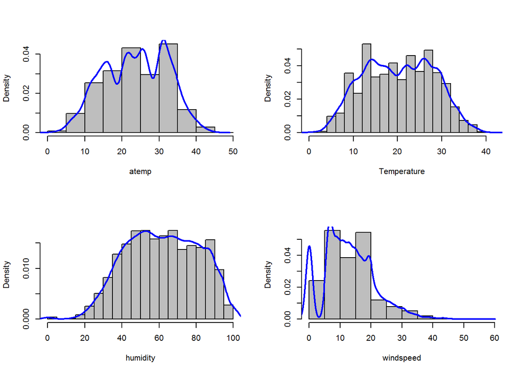

```r
g<-matrix(c(1,2,1,2,3,4,3,4), nrow=4, ncol=2, byrow= TRUE)
layout(g)
#par(mfrow=c(2,2))

hist(training$atemp, xlab = "atemp", prob=TRUE, main = "", col="grey")
lines(density(training$atemp), col="blue", lwd=2)
hist(training$temp, xlab = "Temperature", prob=TRUE, main = "", col="grey")
lines(density(training$temp), col="blue", lwd=2)
hist(training$humidity, xlab = "humidity", prob=TRUE, main = "", col="grey")
lines(density(training$humidity), col="blue", lwd=2)
hist(training$windspeed, xlab = "windspeed", prob=TRUE, main = "", col="grey")
lines(density(training$windspeed), col="blue", lwd=2)
```

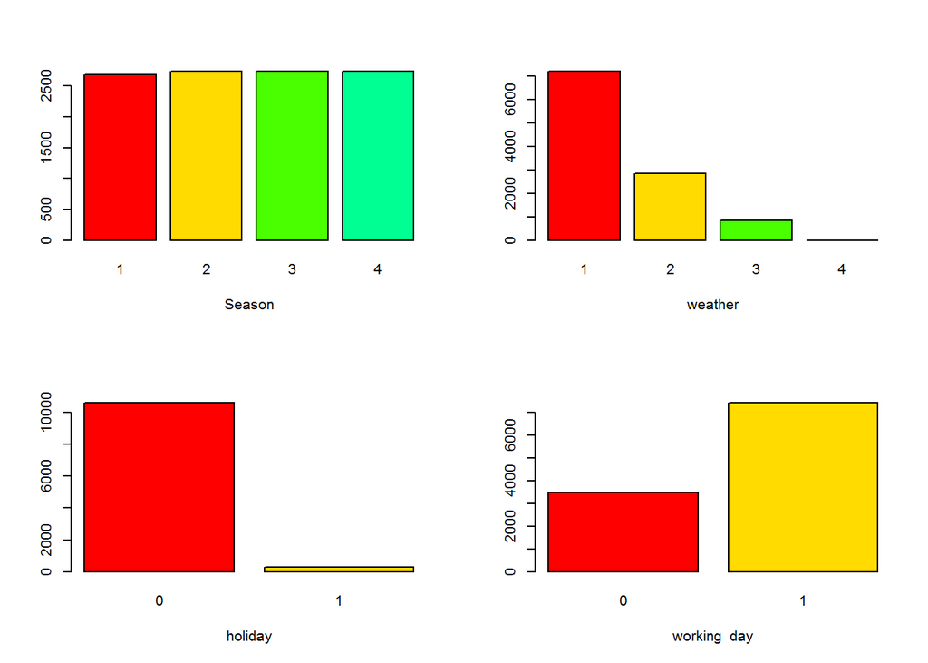

```r
plot(training$season, xlab="Season", col = rainbow(7))
plot(training$weather, xlab="weather", col = rainbow(7))
plot(training$holiday, xlab="holiday", col = rainbow(7))
plot(training$workingday, xlab="working  day", col = rainbow(7))
```

#### Bivariate Analysis

Subsiquent analysis for Casual, Registered, and Count

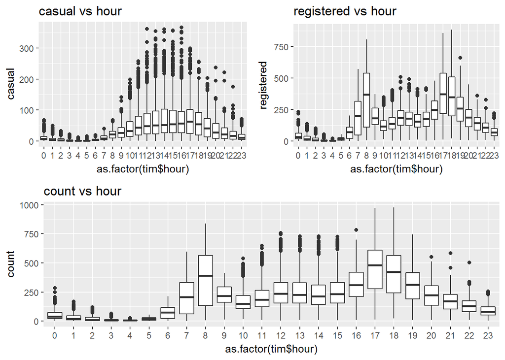

```r
C1_1<-ggplot(training, aes(x=as.factor(tim$hour), y=casual))+ geom_boxplot()+ labs(title="casual vs hour", ylab="Casual", xlab="hour")
C1_2<-ggplot(training, aes(x=as.factor(tim$hour), y=registered))+ geom_boxplot()+ labs(title="registered vs hour", ylab="registered", xlab="hour")
C1_3<-ggplot(training, aes(x=as.factor(tim$hour), y=count))+ geom_boxplot()+ labs(title="count vs hour", ylab="Count", xlab="hour")
#layout(matrix(c(1,2,3,3), nrow = 2, ncol = 2, byrow = TRUE))
#par(mfrow=c(2,2))
#grid.arrange(bp, dp, sc, vp, ncol = 2, layout_matrix = cbind(c(1,1,1), c(2,3,4)))
#grid.arrange(bp, arrangeGrob(dp, sc), ncol = 2)
#layout_matrix <- matrix(c(1, 2, 3, 3), nrow=2, ncol=2, byrow = TRUE)
#layout_matrix <- cbind(c(1,3), c(2,3))

grid.arrange(C1_1, C1_2, C1_3, ncol = 2,layout_matrix = cbind(c(1,3), c(2,3)))
```

On observing the above grapdh it becomes clear that for casual people trend increases from 6 am and generates a peak then dies out around 4 in the next morning.  
while for registered the maximum lies around 8am and around 5 pm.  
These two plot of casual and registered sum together do seems to be consistent with the count.

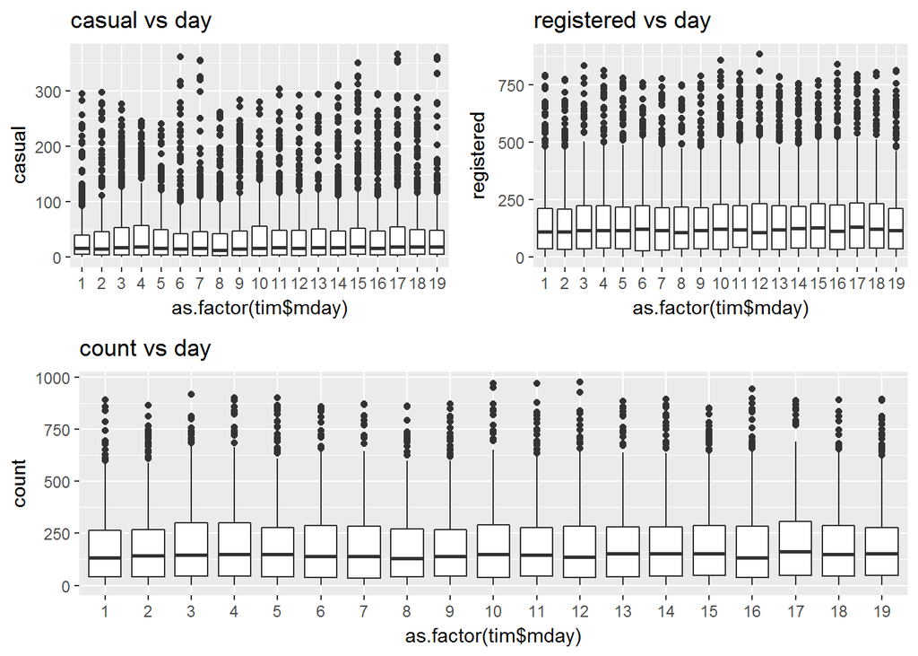

```r
C2_1<-ggplot(training, aes(x=as.factor(tim$mday), y=casual))+ geom_boxplot()+ labs(title="casual vs day", ylab="Casual", xlab="day")
C2_2<-ggplot(training, aes(x=as.factor(tim$mday), y=registered))+ geom_boxplot()+ labs(title="registered vs day", ylab="registered", xlab="day")
C2_3<-ggplot(training, aes(x=as.factor(tim$mday), y=count))+ geom_boxplot()+ labs(title="count vs day", ylab="Count", xlab="day")
grid.arrange(C2_1, C2_2, C2_3, ncol = 2,layout_matrix = cbind(c(1,3), c(2,3)))
```

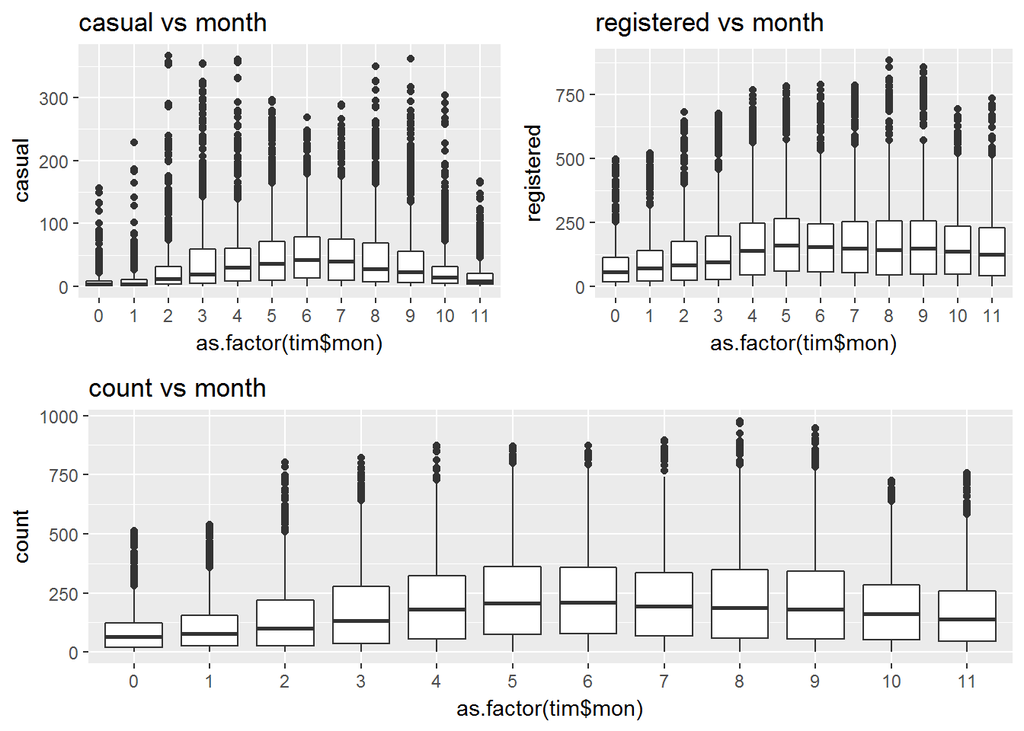

```r
C3_1<-ggplot(training, aes(x=as.factor(tim$mon), y=casual))+ geom_boxplot()+ labs(title="casual vs month", ylab="Casual", xlab="month")
C3_2<-ggplot(training, aes(x=as.factor(tim$mon), y=registered))+ geom_boxplot()+ labs(title="registered vs month", ylab="registered", xlab="month")
C3_3<-ggplot(training, aes(x=as.factor(tim$mon), y=count))+ geom_boxplot()+ labs(title="count vs month", ylab="Count", xlab="month")
grid.arrange(C3_1, C3_2, C3_3, ncol = 2,layout_matrix = cbind(c(1,3), c(2,3)))
```

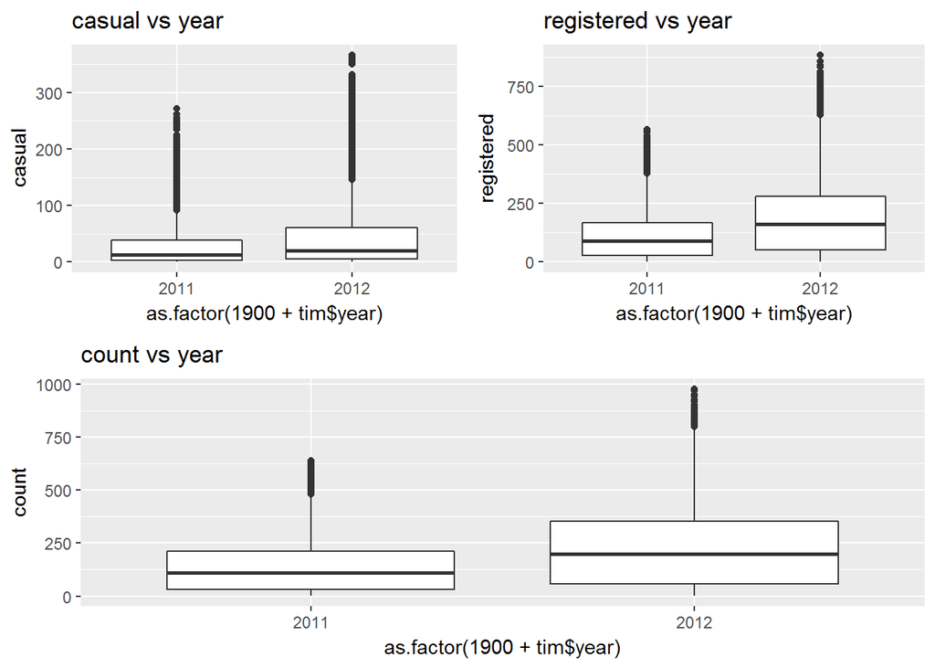

```r
C4_1<-ggplot(training, aes(x=as.factor(1900+tim$year), y=casual))+ geom_boxplot()+ labs(title="casual vs year", ylab="Casual", xlab="year")
C4_2<-ggplot(training, aes(x=as.factor(1900+tim$year), y=registered))+ geom_boxplot()+ labs(title="registered vs year", ylab="registered", xlab="year")
C4_3<-ggplot(training, aes(x=as.factor(1900+tim$year), y=count))+ geom_boxplot()+ labs(title="count vs year", ylab="Count", xlab="year")
grid.arrange(C4_1, C4_2, C4_3, ncol = 2,layout_matrix = cbind(c(1,3), c(2,3)))
```

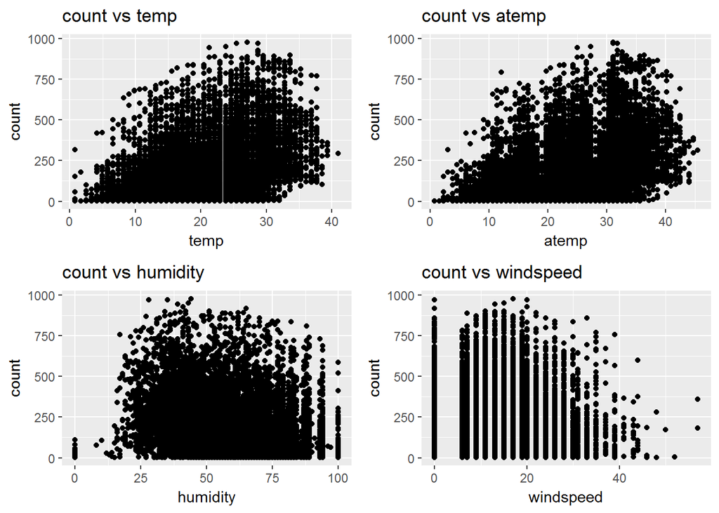

```r
C5_1<-ggplot(training, aes(x=temp, y=count))+ geom_point()+ labs(title="count vs temp", ylab="count", xlab="temp")
C5_2<-ggplot(training, aes(x=atemp, y=count))+ geom_point()+ labs(title="count vs atemp", ylab="count", xlab="atemp")
C5_3<-ggplot(training, aes(x=humidity, y=count))+ geom_point()+ labs(title="count vs humidity", ylab="count", xlab="humidity")
C5_4<-ggplot(training, aes(x=windspeed, y=count))+ geom_point()+ labs(title="count vs windspeed", ylab="count", xlab="windspeed")
grid.arrange(C5_1, C5_2, C5_3, C5_4, ncol = 2,layout_matrix = cbind(c(1,3), c(2,4)))
```

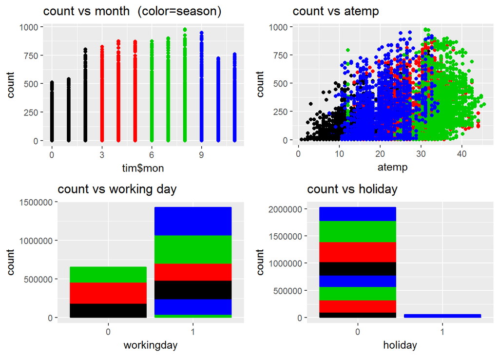

```r
C6_1<-ggplot(training, aes(x=tim$mon, y=count))+ geom_point(col=training$season)+ labs( xlab="month", ylab="count", title="count vs month  (color=season)")
C6_2<-ggplot(training, aes(x=atemp, y=count))+ geom_point(col=training$season)+ labs(title="count vs atemp", ylab="count", xlab="atemp")
C6_3<-ggplot(training, aes(x=workingday, y=count))+ geom_col(col=training$season)+ labs(title="count vs working day", ylab="count", xlab="workingday")
C6_4<-ggplot(training, aes(x=holiday, y=count))+ geom_col(col=training$season)+ labs(title="count vs holiday", ylab="count", xlab="holiday")
grid.arrange(C6_1, C6_2, C6_3, C6_4, ncol = 2,layout_matrix = cbind(c(1,3), c(2,4)))
```

iteration of season color stripe because of the two year data present here also symbolizing the increment of number of people in next season.

### Corelation matrix

Checking the correlation between dependent variable, also checking if the sum of casual and registered is truely equal to count.

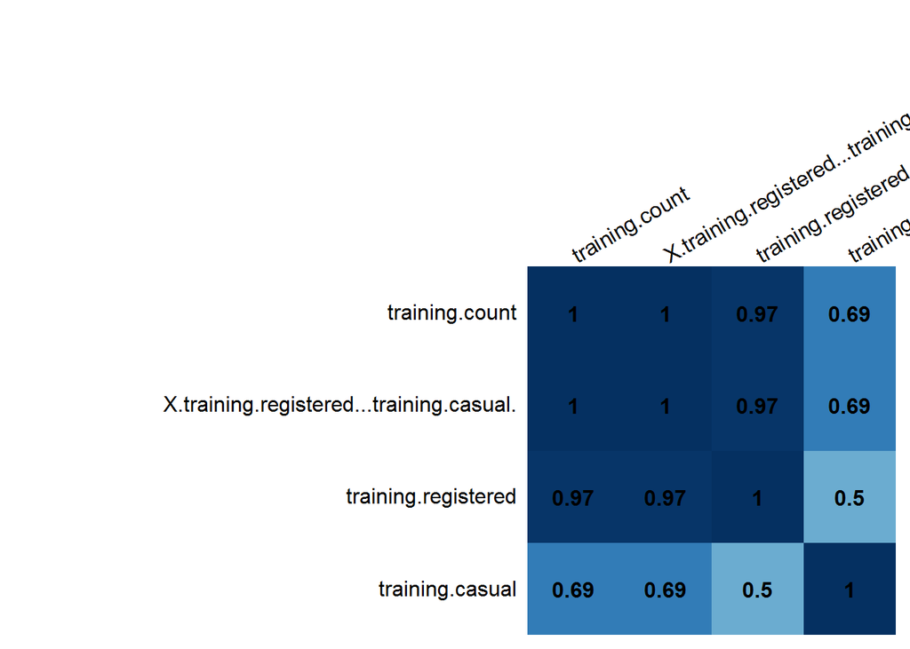

```r
sub1<-data.frame(training$count, (training$registered + training$casual), training$registered, training$casual)
corrplot(cor(sub1), method="shade", shade.col=NA, cl.pos="n", tl.col="black", tl.srt=30, addCoef.col="black")
```

On observing the above plot it becomes clear that indeed count is a proper sum of casual and registered.

Now checkind the relation between dependent and independent variable.

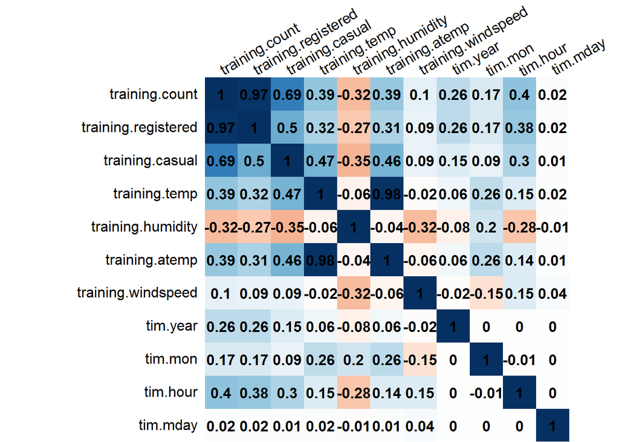

```r
sub2<-data.frame(training$count, training$registered, training$casual, training$temp, training$humidity, training$atemp,training$windspeed, tim$year, tim$mon, tim$hour, tim$mday)
corrplot(cor(sub2), method="shade", shade.col=NA, cl.pos="n", tl.col="black", tl.srt=30, addCoef.col="black")
```

on observing the plot it becomes apparent that which all variable are well correlated with the dependent variable.

## Modeling

moduling the data for testing

```r
tim <- strptime(training$datetime, format='%Y-%m-%d %H:%M:%S')
year <- as.factor(tim$year)
month <- as.factor(tim$mon)
day <- as.integer(tim$mday)
hour <- as.factor(tim$hour)

training<-cbind(year, month, day, hour, training)
str(training)
```

```
## 'data.frame':    10886 obs. of  16 variables:
##  $ year      : Factor w/ 2 levels "111","112": 1 1 1 1 1 1 1 1 1 1 ...
##  $ month     : Factor w/ 12 levels "0","1","2","3",..: 1 1 1 1 1 1 1 1 1 1 ...
##  $ day       : int  1 1 1 1 1 1 1 1 1 1 ...
##  $ hour      : Factor w/ 24 levels "0","1","2","3",..: 1 2 3 4 5 6 7 8 9 10 ...
##  $ datetime  : Factor w/ 10886 levels "2011-01-01 00:00:00",..: 1 2 3 4 5 6 7 8 9 10 ...
##  $ season    : Factor w/ 4 levels "1","2","3","4": 1 1 1 1 1 1 1 1 1 1 ...
##  $ holiday   : Factor w/ 2 levels "0","1": 1 1 1 1 1 1 1 1 1 1 ...
##  $ workingday: Factor w/ 2 levels "0","1": 1 1 1 1 1 1 1 1 1 1 ...
##  $ weather   : Factor w/ 4 levels "1","2","3","4": 1 1 1 1 1 2 1 1 1 1 ...
##  $ temp      : num  9.84 9.02 9.02 9.84 9.84 ...
##  $ atemp     : num  14.4 13.6 13.6 14.4 14.4 ...
##  $ humidity  : int  81 80 80 75 75 75 80 86 75 76 ...
##  $ windspeed : num  0 0 0 0 0 ...
##  $ casual    : int  3 8 5 3 0 0 2 1 1 8 ...
##  $ registered: int  13 32 27 10 1 1 0 2 7 6 ...
##  $ count     : int  16 40 32 13 1 1 2 3 8 14 ...
```

```r
set.seed(12345)
inTrain <- createDataPartition(training$count, p=0.7, list = FALSE)
trainSet <- training[inTrain, ]
str(trainSet)
```

```
## 'data.frame':    7622 obs. of  16 variables:
##  $ year      : Factor w/ 2 levels "111","112": 1 1 1 1 1 1 1 1 1 1 ...
##  $ month     : Factor w/ 12 levels "0","1","2","3",..: 1 1 1 1 1 1 1 1 1 1 ...
##  $ day       : int  1 1 1 1 1 1 1 1 1 1 ...
##  $ hour      : Factor w/ 24 levels "0","1","2","3",..: 1 4 5 8 9 10 11 12 13 14 ...
##  $ datetime  : Factor w/ 10886 levels "2011-01-01 00:00:00",..: 1 4 5 8 9 10 11 12 13 14 ...
##  $ season    : Factor w/ 4 levels "1","2","3","4": 1 1 1 1 1 1 1 1 1 1 ...
##  $ holiday   : Factor w/ 2 levels "0","1": 1 1 1 1 1 1 1 1 1 1 ...
##  $ workingday: Factor w/ 2 levels "0","1": 1 1 1 1 1 1 1 1 1 1 ...
##  $ weather   : Factor w/ 4 levels "1","2","3","4": 1 1 1 1 1 1 1 1 1 2 ...
##  $ temp      : num  9.84 9.84 9.84 8.2 9.84 ...
##  $ atemp     : num  14.4 14.4 14.4 12.9 14.4 ...
##  $ humidity  : int  81 75 75 86 75 76 76 81 77 72 ...
##  $ windspeed : num  0 0 0 0 0 ...
##  $ casual    : int  3 3 0 1 1 8 12 26 29 47 ...
##  $ registered: int  13 10 1 2 7 6 24 30 55 47 ...
##  $ count     : int  16 13 1 3 8 14 36 56 84 94 ...
```

```r
V_Set <- training[-inTrain, ]


#testing data manuplation
testing$season<-as.factor(testing$season)
testing$holiday<-as.factor(testing$holiday)
testing$workingday<-as.factor(testing$workingday)
testing$weather<-as.factor(testing$weather)

tim <- strptime(testing$datetime, format='%Y-%m-%d %H:%M:%S')
year <- as.factor(tim$year)
month <- as.factor(tim$mon)
day <- as.integer(tim$mday)
hour <- as.factor(tim$hour)

testing <-cbind(year, month, day, hour, testing)
str(testing)
```

```
## 'data.frame':    6493 obs. of  13 variables:
##  $ year      : Factor w/ 2 levels "111","112": 1 1 1 1 1 1 1 1 1 1 ...
##  $ month     : Factor w/ 12 levels "0","1","2","3",..: 1 1 1 1 1 1 1 1 1 1 ...
##  $ day       : int  20 20 20 20 20 20 20 20 20 20 ...
##  $ hour      : Factor w/ 24 levels "0","1","2","3",..: 1 2 3 4 5 6 7 8 9 10 ...
##  $ datetime  : Factor w/ 6493 levels "2011-01-20 00:00:00",..: 1 2 3 4 5 6 7 8 9 10 ...
##  $ season    : Factor w/ 4 levels "1","2","3","4": 1 1 1 1 1 1 1 1 1 1 ...
##  $ holiday   : Factor w/ 2 levels "0","1": 1 1 1 1 1 1 1 1 1 1 ...
##  $ workingday: Factor w/ 2 levels "0","1": 2 2 2 2 2 2 2 2 2 2 ...
##  $ weather   : Factor w/ 4 levels "1","2","3","4": 1 1 1 1 1 1 1 1 1 2 ...
##  $ temp      : num  10.7 10.7 10.7 10.7 10.7 ...
##  $ atemp     : num  11.4 13.6 13.6 12.9 12.9 ...
##  $ humidity  : int  56 56 56 56 56 60 60 55 55 52 ...
##  $ windspeed : num  26 0 0 11 11 ...
```

#### Result score obtained from kaggle will be shown

Submission were done on my profile and there score of the build model will be shown below that.

[figure not shown]

### 1.Creating model using tree

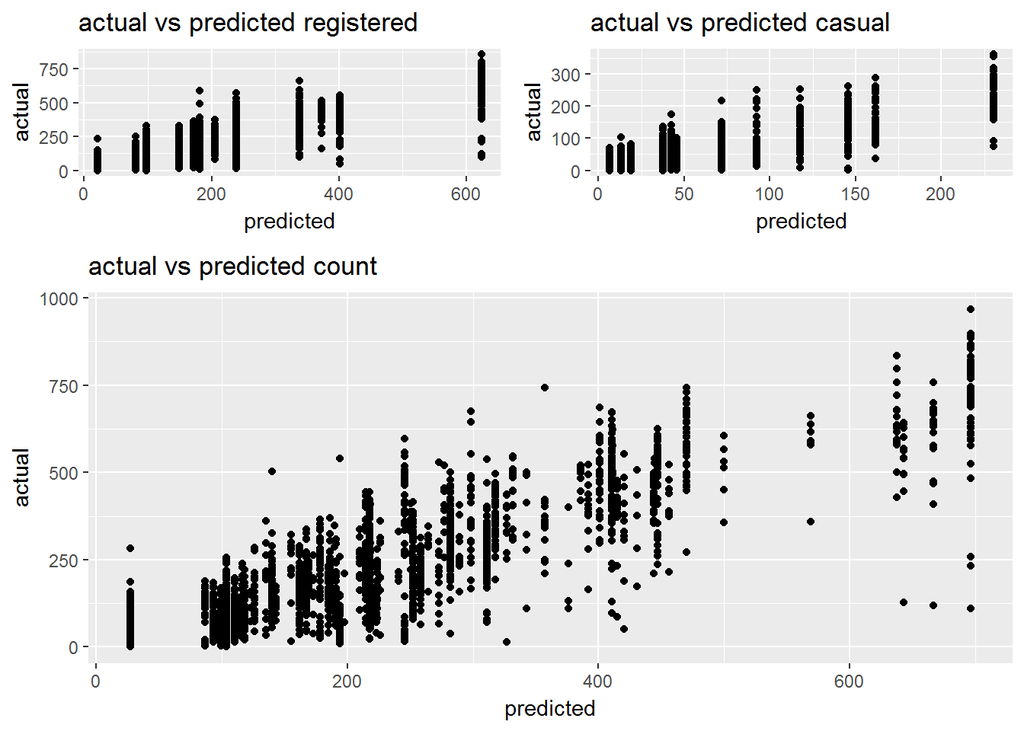

```r
# atemp is highly corelated to temp, no much variation between day,
set.seed(12424)
#modfit1_1 <- rpart(training$registered ~ . - training$casual - training$count - training$atemp, data = training)
modfit1_1 <- rpart(registered ~ year + month + hour + season + holiday + workingday + weather + temp + humidity + windspeed, data = trainSet)
modfit1_2 <- rpart(casual ~ year + month + hour + season + holiday + workingday + weather + temp + humidity + windspeed, data = trainSet)

# Evaluating the result on validation Set
#logpred1 <- predict(modfit1_1,V_Set)
#reg <- logpred1 #exp(logpred1)
#logpred2 <- predict(modfit1_2,V_Set)
#cas=exp(logpred2)
#cou <- reg + cas
reg1<-predict(modfit1_1, V_Set)
cas1<-predict(modfit1_2, V_Set)
cou1<-reg1+cas1


R1<-qplot(reg1, V_Set$registered, main="actual vs predicted registered", xlab = "predicted", ylab = "actual")
#a<-lm(CV_Set$registered~reg)
#abline(coef(a), lwd=2)
R2<-qplot(cas1, V_Set$casual, main="actual vs predicted casual", xlab = "predicted", ylab = "actual")
R3<-qplot(cou1, V_Set$count, main="actual vs predicted count", xlab = "predicted", ylab = "actual")
grid.arrange(R1, R2, R3, ncol = 2,layout_matrix = cbind(c(1,3,3), c(2,3,3)))
```

```r
#summary(modfit1_1)
#summary(modfit1_2)
#print(modfit1_1)
#print(modfit1_2)
#plot(modfit1_1)
#text(modfit1_1, use.n=TRUE, all=TRUE, cex=0.45)
#fancyRpartPlot(modfit1_1)
#plot(modfit1_2)
#text(modfit1_2, use.n=TRUE, all=TRUE, cex=0.45)

cor(cou1, V_Set$count)
```

```
## [1] 0.8936063
```

```r
sqrt(sum((V_Set$count - cou1)^2) / nrow(V_Set))
```

```
## [1] 81.24182
```

```r
registered <- predict(modfit1_1, testing)
casual <- predict(modfit1_2, testing)
count <- registered + casual
testing <- cbind(testing, registered, casual, count)
#str(testing)
s<-data.frame(datetime=testing$datetime,count=testing$count)
write.csv(s,file="1-submit(tree).csv",row.names=FALSE)
# File will be written and saved in working directory
```

##### Submission Score

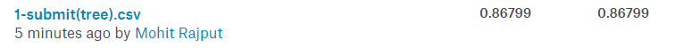

### 2.Creating model using random forest

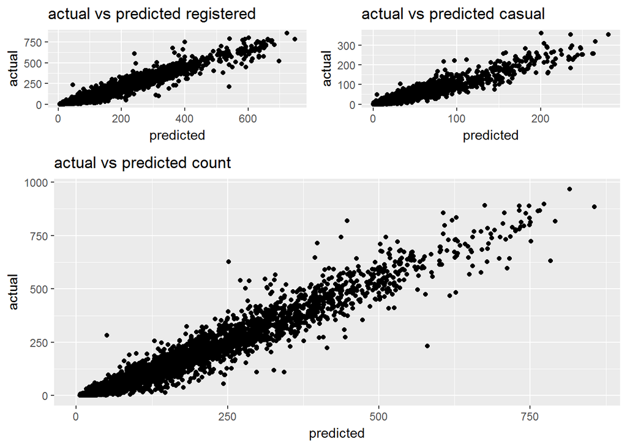

```r
# atemp is highly corelated to temp, no much variation between day,
set.seed(14231)
modfit2_1 <- randomForest(registered ~ year + month + hour + season + holiday + workingday + weather + temp + humidity + windspeed, data = trainSet)
modfit2_2 <- randomForest(casual ~ year + month + hour + season + holiday + workingday + weather + temp + humidity + windspeed, data = trainSet)

# Evaluating the result on validation Set
reg2<-predict(modfit2_1, V_Set)
cas2<-predict(modfit2_2, V_Set)
cou2<-reg2+cas2

R1<-qplot(reg2, V_Set$registered, main="actual vs predicted registered", xlab = "predicted", ylab = "actual")
#a<-lm(CV_Set$registered~reg)
#abline(coef(a), lwd=2)
R2<-qplot(cas2, V_Set$casual, main="actual vs predicted casual", xlab = "predicted", ylab = "actual")
R3<-qplot(cou2, V_Set$count, main="actual vs predicted count", xlab = "predicted", ylab = "actual")
grid.arrange(R1, R2, R3, ncol = 2,layout_matrix = cbind(c(1,3,3), c(2,3,3)))
```

```r
#plot(modfit2_1)
#text(modfit2_1, use.n=TRUE, all=TRUE, cex=0.45)
#plot(modfit2_2)
#text(modfit2_2, use.n=TRUE, all=TRUE, cex=0.45)

cor(cou2, V_Set$count)
```

```
## [1] 0.9660479
```

```r
sqrt(sum((V_Set$count - cou2)^2) / nrow(V_Set))
```

```
## [1] 50.04595
```

```r
registered2 <- predict(modfit2_1, testing)
casual2 <- predict(modfit2_2, testing)
count2 <- registered2 + casual2
testing <- cbind(testing, registered2, casual2, count2)
s<-data.frame(datetime=testing$datetime,count=testing$count2)
write.csv(s,file="2-submit(randomForest).csv",row.names=FALSE)
# File will be written and saved in working directory
```

##### Submission Score

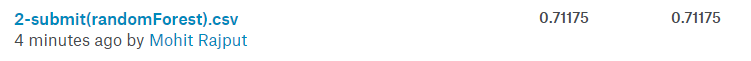

### 3.Creating model using tree with complete training set

```r
# atemp is highly corelated to temp, no much variation between day,
set.seed(22349)
modfit3_1 <- rpart(registered ~ year + month + hour + season + holiday + workingday + weather + temp + humidity + windspeed, data = training)
modfit3_2 <- rpart(casual ~ year + month + hour + season + holiday + workingday + weather + temp + humidity + windspeed, data = training)


registered3 <- predict(modfit3_1, testing)
casual3 <- predict(modfit3_2, testing)
count3 <- registered3 + casual3
testing <- cbind(testing, registered3, casual3, count3)
s<-data.frame(datetime=testing$datetime,count=testing$count3)
write.csv(s,file="3-submit(Tree_complete_trainSet).csv",row.names=FALSE)
# File will be written and saved in working directory
```

##### Submission Score

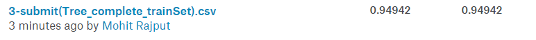

### 4.Creating model using random forest with complete training set

```r
# atemp is highly corelated to temp, no much variation between day,
set.seed(12422)
modfit4_1 <- randomForest(registered ~ year + month + hour + season + holiday + workingday + weather + temp + humidity + windspeed, data = training)
modfit4_2 <- randomForest(casual ~ year + month + hour + season + holiday + workingday + weather + temp + humidity + windspeed, data = training)


registered4 <- predict(modfit4_1, testing)
casual4 <- predict(modfit4_2, testing)
count4 <- registered4 + casual4
testing <- cbind(testing, registered4, casual4, count4)
s<-data.frame(datetime=testing$datetime,count=testing$count4)
write.csv(s,file="4-submit(randomForest_complete_trainSet).csv",row.names=FALSE)
# File will be written and saved in working directory
```

##### Submission Score

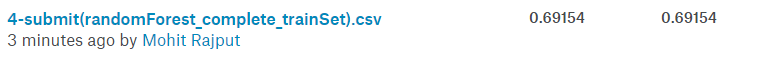

```r
# atemp is highly corelated to temp, no much variation between day,
Ntemp <-  data.Normalization (training$temp,type="n1",normalization="column")
Nhumidity <-  data.Normalization (training$humidity,type="n1",normalization="column")
Nwindspeed <-  data.Normalization (training$windspeed,type="n1",normalization="column")
training<-cbind(Ntemp, Nhumidity, Nwindspeed, training)


Ntemp <-  data.Normalization (testing$temp,type="n1",normalization="column")
Nhumidity <-  data.Normalization (testing$humidity,type="n1",normalization="column")
Nwindspeed <-  data.Normalization (testing$windspeed,type="n1",normalization="column")
testing<-cbind(Ntemp, Nhumidity, Nwindspeed, testing)


set.seed(78942)
modfit5_1 <- randomForest(registered ~ year + month + hour + season + holiday + workingday + weather + Ntemp + Nhumidity + Nwindspeed, data = training)
modfit5_2 <- randomForest(casual ~ year + month + hour + season + holiday + workingday + weather + Ntemp + Nhumidity + Nwindspeed, data = training)


registered5 <- predict(modfit5_1, testing)
casual5 <- predict(modfit5_2, testing)
count5 <- registered5 + casual5
testing <- cbind(testing, registered5, casual5, count5)
s<-data.frame(datetime=testing$datetime,count=testing$count5)
write.csv(s,file="5-submit(randomForest_complete_trainSet_with_Normalized_int).csv",row.names=FALSE)
# File will be written and saved in working directory
```

##### Submission Score

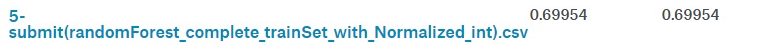